# Assignment 1 Data selection

Xiaofeng Li

2026-02-07

# Loading Data

This dataset was obtained from the Gene Expression Omnibus (GEO) under accession GSE104674 (Stenvers, Jongejan, and others 2019) (Davis and Meltzer 2007) (Wickham et al. 2019).

```r
gse <- getGEO(
    "GSE104674",
    GSEMatrix = TRUE,
    getGPL = FALSE
)
eset <- gse[[1]]

counts <- read.table(
  "./GSE104674/GSE104674_rawCounts.txt.gz",
  header = TRUE,
  row.names = 1,
  sep = "\t",
  check.names = FALSE
)
pheno <- pData(eset)
pheno$group <- factor(
  ifelse(
    grepl("Healthy", pheno$characteristics_ch1),
    "control",
    "diabetes"
  ),
  levels = c("control", "diabetes")
)
pheno <- pheno %>%
  mutate(
    subject_id = str_extract(characteristics_ch1.1, "\\d+$"),
    subject_id = str_pad(subject_id, width = 2, side = "left", pad = "0"),
    timepoint  = str_extract(title, "D\\d+:\\d+"),
    timepoint  = str_replace(timepoint, ":", "_"),
    sample_name = paste0("Rhythm", subject_id, "_", timepoint)
  )
rownames(pheno) <- pheno$sample_name
pheno <- dplyr::select(pheno, group)
```

### Data Clean

For differential expression analyze, lowly expressed genes were filtered using the edgeR framework (Robinson et al. 2010) associated with a designed matrix. First, a DGEList object is constructed based on the original read counts, and a design matrix is built by combining the experimental group information. Then, the filterByExpr() function is used to filter low-expression genes using the design matrix, requiring that the gene show expression signals detected in at least one read in a subset of samples within at least one experimental group. This removes genes that are almost undetectable under all conditions and lack statistical information, while retaining genes that may be expressed under specific conditions or in a small number of samples.

```r
dge <- DGEList(counts = counts)
dim(dge)
```

```
## [1] 24364    48
```

```r
design <- model.matrix(~ 0 + group, data = pheno)
keep <- filterByExpr(dge, design, min.count = 1)
dge <- dge[keep, , keep.lib.sizes = FALSE]
dim(dge)
```

```
## [1] 15335    48
```

```r
counts_final <- dge$counts
```

# Data distribution

### Density plot（log2 counts）

To see the original distribution of counts in different samples, I plotted the density plot.

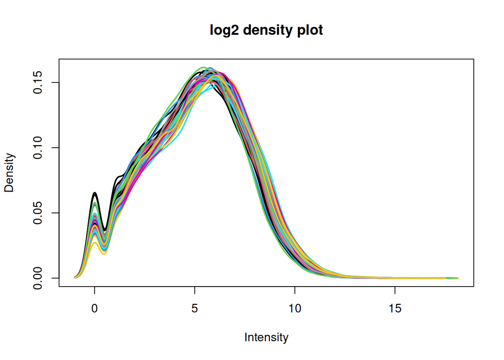

```r
des <- as.matrix(counts_final)
log_counts <- log2(des + 1)
plotDensities(log_counts, legend = FALSE, main ="log2 density plot")
```

**Figure 1. Log2 transformed gene expression intensity density distribution plot.** This plot shows the overall expression level distribution of each sample. Different colored curves represent different samples, and their distribution shapes are highly similar, indicating that the overall expression distribution among samples is consistent.

### Boxplot

The boxplot be used to see if there are some sample with extrem large or small counts which should be outliers.

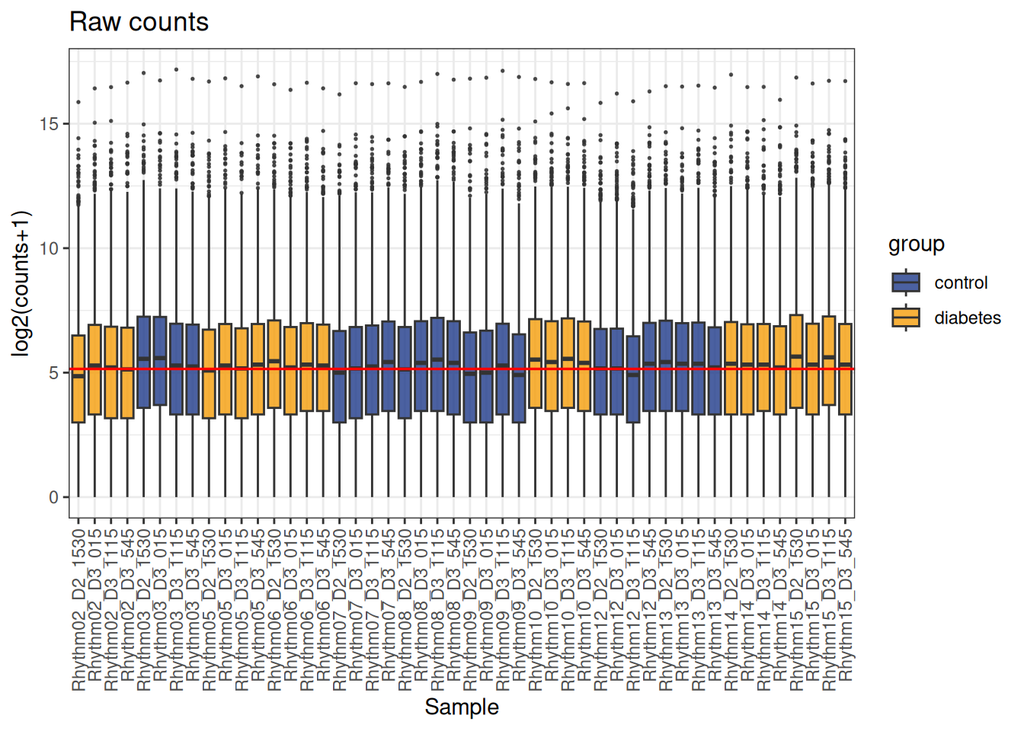

```r
plot_box <- function(mat, pheno, main = "", ylab = "log2(counts+1)") {
  df_long <- as.data.frame(mat) |>
    rownames_to_column("gene") |>
    pivot_longer(-gene, names_to = "sample", values_to = "value") |>
    left_join(pheno |> rownames_to_column("sample"), by = "sample") |>
    mutate(value = log2(value + 1))

  overall_mean <- mean(df_long$value, na.rm = TRUE)

  ggplot(df_long, aes(x = sample, y = value, fill = group)) +
    geom_boxplot(outlier.size = 0.3, alpha = 0.8) +
    geom_hline(yintercept = overall_mean, color = "red", linewidth = 0.6) +
    scale_fill_manual(values = c(control = "#1F3A8A", diabetes = "#F59E0B")) +
    theme_bw() +
    theme(axis.text.x = element_text(angle = 90, vjust = 0.5, hjust = 1)) +
    labs(title = main, x = "Sample", y = ylab)
}

p_raw <- plot_box(counts_final, pheno, main = "Raw counts")
p_raw
```

# ID mapping

### Raw counts format

First, I checked the original counts gene indentifier format, and found they already be HUGO symbols but have some additional information.

```r
head(rownames(counts_final))
```

```
## [1] "LOC100288069:chr1:NR_033908" "NCRNA00115:chr1:NR_024321"
## [3] "LOC643837:chr1:NR_015368"    "SAMD11:chr1:NM_152486"
## [5] "NOC2L:chr1:NM_015658"        "KLHL17:chr1:NM_198317"
```

### Mapping

We can find the format of gene identifier is `gene_name:transcript_ID`. Thus, we need to merge all transcripts of one gene into a single count.

```r
gene_symbol <- sub(":.*$", "", rownames(counts_final))
counts_df <- data.frame(
  gene_symbol = gene_symbol,
  counts_final,
  check.names = FALSE
)
counts_final <- counts_df %>%
  group_by(gene_symbol) %>%
  summarise(across(where(is.numeric), sum))
counts_final <- as.data.frame(counts_final)
rownames(counts_final) <- counts_final$gene_symbol
counts_final$gene_symbol <- NULL
```

After re-formate the row name, I used biomaRt to check if these names are all official HUGO symbols (Durinck et al. 2009). 2385 un-mapped genes founded by this step.

```r
gene_symbols <- rownames(counts_final)

bm_hgnc <- getBM(
  attributes = c("hgnc_symbol"),
  filters    = "hgnc_symbol",
  values     = gene_symbols,
  mart       = mart
)

valid_symbols <- unique(bm_hgnc$hgnc_symbol)
not_found <- setdiff(gene_symbols, valid_symbols)
length(not_found)
```

```
## [1] 2385
```

To solve that I mapped these gene as alias name using biomaRt and tring to match the official name (Durinck et al. 2009).

```r
alias_map <- getBM(
  attributes = c(
    "hgnc_symbol",
    "external_synonym"
  ),
  filters = "external_synonym",
  values  = not_found,
  mart    = mart
)
alias_founded <- alias_map |>
  dplyr::filter(hgnc_symbol != "") |>
  dplyr::distinct(external_synonym, hgnc_symbol) |>
  dplyr::group_by(external_synonym) |>
  dplyr::filter(n() == 1) |>
  dplyr::ungroup()
nrow(alias_founded)
```

```
## [1] 1814
```

### Finish Mapping

In the end, I replaced the alias name by matched HUGO symbol, and dropped all unmathed genes. Then I merged the dupulication in HUGO symbol.

```r
alias_map_vec <- setNames(alias_founded$hgnc_symbol,alias_founded$external_synonym)
old_symbols <- rownames(counts_final)
is_standard <- old_symbols %in% valid_symbols
is_alias    <- old_symbols %in% names(alias_map_vec)
new_symbols <- old_symbols
new_symbols[is_alias] <- alias_map_vec[old_symbols[is_alias]]
keep_genes <- is_standard | is_alias
counts_clean <- counts_final[keep_genes, ]
new_symbols  <- new_symbols[keep_genes]
counts_clean$gene <- new_symbols
counts_clean <- counts_clean |>
  group_by(gene) |>
  summarise(across(where(is.numeric), sum)) |>
  as.data.frame()
rownames(counts_clean) <- counts_clean$gene
counts_clean$gene <- NULL
counts_final <- counts_clean
anyDuplicated(rownames(counts_final))
```

```
## [1] 0
```

```r
dge <- DGEList(counts = counts_final)
```

# Normalization

When the data is cleaned, mapped and checked the original distribution with no outliers, it can be used in normalization process to make sure all gene counts in the same level so we can compare by analyze.

### Size Factor normalization

Given that the differences between samples are not significant and there are no extreme samples, and based on the objective of differential expression analysis, I will use DESeq2 size factor method for normalization.

```r
dds <- DESeqDataSetFromMatrix(
  countData = counts_final,
  colData = pheno,
  design = ~ group
)

dds <- estimateSizeFactors(dds)
norm_counts <- counts(dds, normalized = TRUE)
```

### MDS plot

Using MDS plot, we can check the seperation status of normalized data.

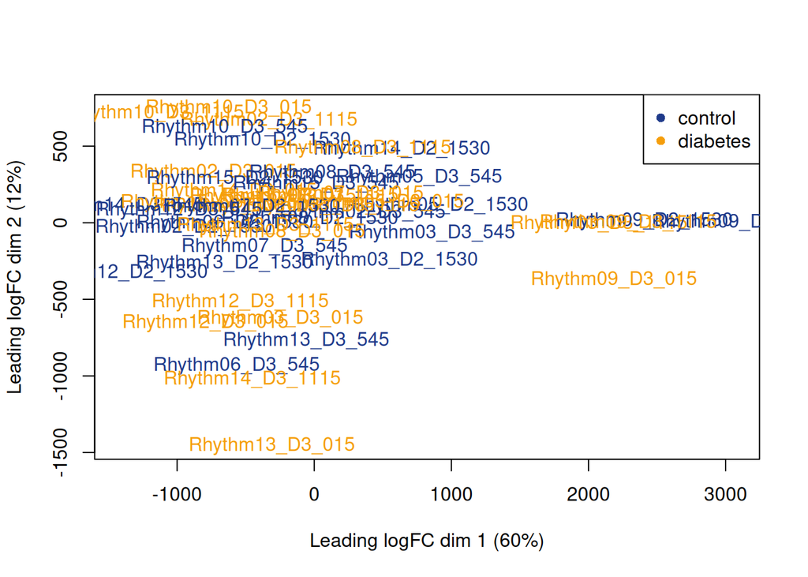

```r
plotMDS(
  norm_counts,
  col = c("#1F3A8A", "#F59E0B"),
  labels = NULL
)

legend(
  "topright",
  legend = levels(pheno$group),
  col = c("#1F3A8A", "#F59E0B"),
  pch = 16
)
```

### Comparsion

After normalization, I checked the boxplot again and compared with the raw data to see how normalization affect the data.

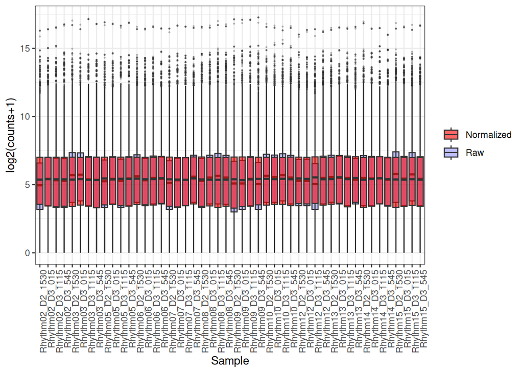

```r
plot_box_overlay <- function(raw_mat, norm_mat,
                             ylab = "log2(counts+1)") {

  df_raw <- as.data.frame(raw_mat) |>
    rownames_to_column("gene") |>
    pivot_longer(-gene, names_to = "sample", values_to = "value") |>
    mutate(
      value = log2(value + 1),
      type = "Raw"
    )

  df_norm <- as.data.frame(norm_mat) |>
    rownames_to_column("gene") |>
    pivot_longer(-gene, names_to = "sample", values_to = "value") |>
    mutate(
      value = log2(value + 1),
      type = "Normalized"
    )

  df_long <- bind_rows(df_raw, df_norm)

  ggplot(df_long, aes(x = sample, y = value)) +
    geom_boxplot(
      data = df_long |> filter(type == "Raw"),
      aes(fill = "Raw"),
      alpha = 0.25,
      outlier.size = 0.3
    ) +
    geom_boxplot(
      data = df_long |> filter(type == "Normalized"),
      aes(fill = "Normalized"),
      alpha = 0.6,
      outlier.size = 0.3
    ) +
    scale_fill_manual(
      values = c(Normalized = "red", Raw = "blue")
    ) +
    theme_bw() +
    theme(
      axis.text.x = element_text(angle = 90, hjust = 1)
    ) +
    labs(x = "Sample", y = ylab, fill = "")
}
plot_box_overlay(counts_final, norm_counts)
```

**Figure 4. Box plot comparison of raw counts and Size Factor-normalized expression values under log2(counts + 1) transformation.** The blue box represents the expression distribution before normalization, and the red box represents the expression distribution after normalization. The expression distribution of different samples is more aligned after normalization.

### Final Data

Now, a clean, mapped and normalized data can be used for future analyze.

```r
dim(norm_counts)
```

```
## [1] 14100    48
```

```r
head(norm_counts[1:6,1:4])
```

```
##          Rhythm02_D2_1530 Rhythm02_D3_015 Rhythm02_D3_545 Rhythm02_D3_1115
## A1BG             1.345794       1.9627635        3.229460         1.051243
## A1BG-AS1         1.345794       0.9813818        4.305947         2.102486
## A2M           1157.382617    1460.2960510     1712.690394      1671.476109
## A2ML1            0.000000       3.9255270        3.229460         1.051243
## A4GALT           4.037381       6.8696723       10.764867        14.717400
## A4GNT            2.691587       3.9255270        2.152973         4.204971
```

# Differential Gene Expression

### DESeq2

I will use DESeq2, which is based on a negative binomial distribution model (Love et al. 2014). For the accuracy of the p-value, I filtered out all genes with expression levels in (see data clean) stage.

```r
dds <- DESeq(dds)
res <- results(dds, contrast = c("group", "diabetes", "control"))
res_df <- as.data.frame(res) |> rownames_to_column("gene")
res_df <- res_df |>
  mutate(sig = case_when(
    padj < 0.01 & log2FoldChange > 1  ~ "Up",
    padj < 0.01 & log2FoldChange < -1 ~ "Down",
    TRUE ~ "NS"
  ))
UP <- res_df %>%
  filter(!is.na(padj)) %>%
  filter(padj < 0.01, log2FoldChange > 1)
Down <- res_df %>%
  filter(!is.na(padj)) %>%
  filter(padj < 0.01, log2FoldChange < 1)
```

### Calculate p-values for each of the genes in your expression set. How many genes were significantly differentially expressed? What thresholds did you use and why?

```r
nrow(UP)
```

```
## [1] 92
```

```r
nrow(Down)
```

```
## [1] 1471
```

### Volcano Plot

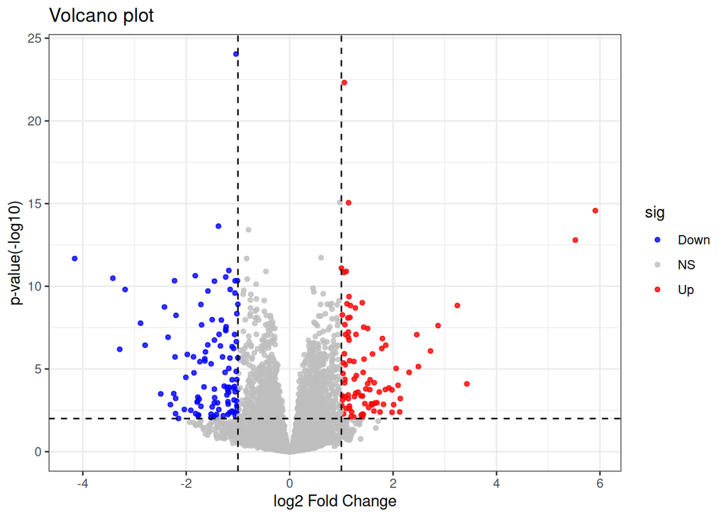

```r
ggplot(res_df, aes(x = log2FoldChange, y = -log10(padj), color = sig)) +
  geom_point(size = 1.2, alpha = 0.8) +
  scale_color_manual(values = c(Up = "red", Down = "blue", NS = "grey")) +
  geom_vline(xintercept = c(-1, 1), linetype = "dashed") +
  geom_hline(yintercept = -log10(0.01), linetype = "dashed") +
  theme_bw() +
  labs(title = "Volcano plot", x = "log2 Fold Change", y = "p-value(-log10)")
```

### Heatmap

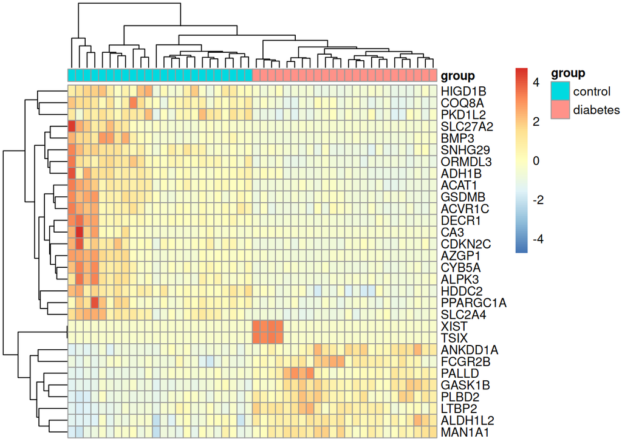

```r
library(pheatmap)

top_genes <- res_df %>%
  filter(!is.na(padj)) %>%
  arrange(padj) %>%
  slice_head(n = 30) %>%
  pull(gene)

mat <- norm_counts[top_genes, ]

pheatmap(
  mat,
  scale = "row",
  annotation_col = pheno,
  clustering_distance_rows = "euclidean",
  clustering_distance_cols = "euclidean",
  clustering_method = "complete",
  show_colnames = FALSE
)
```

# Interpret

### What are the control and test conditions of the dataset?

In this data set, the control group consisted of healthy, lean individuals, while the experimental group consisted of obese patients with type 2 diabetes. The samples were all collected from subcutaneous adipose tissue under controlled food intake and fixed Zeitgeber Time conditions. The control and test conditions were defined in the phenotype processing step group definition.

### Why is the dataset of interest to you?

Firstly, I am very interested in the research topic of this dataset. Obesity and diabetes are mutually influential, and this dataset collects adipose tissue from diabetic patients for study. (Stenvers, Jongejan, Atiqi, et al. 2019) My research could focus on whether gene expression affects the development of diabetes, or whether certain genes are suppressed in the adipose tissue of diabetic patients. Secondly, the data quality is very high. This is high-throughput RNA-seq data, and the supplementary data contains raw counts, making it very suitable for differential expression analysis. It contains 48 samples from 12 individuals at different time points, ensuring sufficient sample size and reproducibility, which greatly improves the accuracy of the data. My normalization boxplot and density plot show no extreme data points, and the data is even more stable after normalization, indicating high reliability.

### Were there expression values that were not unique for specific genes? How did you handle these?

In this dataset, genes are calculated separately for each transcript, meaning the same gene may exist in multiple transcripts, resulting in duplicates in the raw counts. process data Since my focus here is on gene-level analysis, I combined different transcripts for the same gene for calculation. If further transcript-level analysis is needed in subsequent analyses, I have also retained the raw counts data frame for use.

### How many outliers were removed?

Outliers were not removed at the sample level. As I mentioned, the sample distribution was clearly checked using density plots and boxplots, and the captions indicate that no obvious outliers were found, therefore no sample removal was performed. However, due to the extremely low total expression of some genes, if the test or control showed expression levels of 0, it would lead to complete segregation, resulting in a Na p-value in the final DESeq2 analysis. This is normal because some genes are inherently low in expression. However, because differential expression analysis is required, even without removing these genes, the extremely low expression amplifies the impact of full fractional expression (FC). Small sequencing variances can significantly affect the p-value. Therefore, an edge filter combined with a design matrix was used to remove genes that lack expression support under any condition. 9029 genes are removed by code.

### How did you handle replicates?

For each individual, the dataset contains four samples taken at different times. These are multiple independent samples, not technical replicates, so instead of averaging or merging replicates, I treated each sample as an independent observation and directly incorporated it into the statistical model. This approach effectively assigns equivalent weights to different times of day, avoiding variance caused by different sampling times (e.g., control samples taken entirely before meals while test samples taken entirely after meals). Furthermore, the time information can be used in subsequent studies as a grouping criterion to investigate differences in gene expression among diabetic patients at different times. In the code, I extracted the individual identifier and sampling time from the pheno data and set them as the row name of the sample to keep them consistent with the counts.

# References

Davis, Sean, and Paul S. Meltzer. 2007. “GEOquery: A Bridge Between the Gene Expression Omnibus (GEO) and BioConductor.” *Bioinformatics* 23 (14): 1846–47. https://doi.org/10.1093/bioinformatics/btm254.

Durinck, Steffen, Paul T. Spellman, Ewan Birney, and Wolfgang Huber. 2009. “Mapping Identifiers for the Integration of Genomic Datasets with the r/Bioconductor Package biomaRt.” *Nature Protocols* 4 (8): 1184–91. https://doi.org/10.1038/nprot.2009.97.

Love, Michael I., Wolfgang Huber, and Simon Anders. 2014. “Moderated Estimation of Fold Change and Dispersion for RNA-Seq Data with DESeq2.” *Genome Biology* 15 (12): 550. https://doi.org/10.1186/s13059-014-0550-8.

Robinson, Mark D., Davis J. McCarthy, and Gordon K. Smyth. 2010. “edgeR: A Bioconductor Package for Differential Expression Analysis of Digital Gene Expression Data.” *Bioinformatics* 26 (1): 139–40. https://doi.org/10.1093/bioinformatics/btp616.

Stenvers, Dirk J., Arjen Jongejan, et al. 2019. *The Diurnal Rhythm of Adipose Tissue Gene Expression Is Reduced in Obese Patients with Type 2 Diabetes*. [Https://www.ncbi.nlm.nih.gov/geo/query/acc.cgi?acc=GSE104674](https://www.ncbi.nlm.nih.gov/geo/query/acc.cgi?acc=GSE104674).

Stenvers, Dirk J., Arjen Jongejan, Sara Atiqi, Jeroen P. Vrijling, et al. 2019. “Diurnal Rhythms in the White Adipose Tissue Transcriptome Are Disturbed in Obese Individuals with Type 2 Diabetes Compared with Lean Control Individuals.” *Diabetologia* 62 (4): 704–16. https://doi.org/10.1007/s00125-019-4815-1.

Wickham, Hadley, Mara Averick, Jennifer Bryan, et al. 2019. “Welcome to the Tidyverse.” *Journal of Open Source Software* 4 (43): 1686. https://doi.org/10.21105/joss.01686.